# Data construction: Crop suitability

Dr. Emily Burchfield

This document describes the data and scripts used to construct the presence/absence panels used to calibrate historical crop suitability models and project future suitability. We define each crop’s presence/absense using the following categories from the [USDA Cropland Data Layer](https://nassgeodata.gmu.edu/CropScape/):

- **Corn**: Corn (1), Dbl Crop WinWht/Corn (225), Dbl Crop Oats/Corn (226), Dbl Crop Triticale/Corn (228), Dbl Crop Barley/Corn (237), DblCrop Corn/Soybeans (241)[^1]
- **Winter wheat**: Winter wheat (24), Dbl Crop WinWht/Corn (225), Dbl Crop WinWht/Sorghum (236), Dbl Crop WinWht/Cotton (238), DblCrop Winwht/Soybeans (26)
- **Soybeans**: Soybeans (5), DblCrop Soybeans/Cotton (239), DblCrop Soybeans/Oats (240), DblCrop Corn/Soybeans (241), DblCrop Winwht/Soybeans (26), DblCrop Barley/Soybeans (254)
- **Cotton**: Cotton (2), Dbl Crop Lettuce/Cotton (232), Dbl Crop WinWht/Cotton (238), Dbl Crop Soybeans/Cotton (239)
- **Spring wheat**: Spring wheat (23)
- **Alfalfa**: Alfalfa (36),
- **Hay**: Other hay/non-alfalfa (37)

## Biophysical suitability analyses

### ROI

Our region of interest includes the following states:

Maine, North Dakota, South Dakota, Wisconsin, Vermont, Minnesota, New Hampshire, Iowa, Massachusetts, Nebraska, New York, Pennsylvania, Connecticut, Rhode Island, New Jersey, Indiana, Ohio, Illinois, District of Columbia, Delaware, West Virginia, Maryland, Kentucky, Kansas, Virginia, Missouri, Oklahoma, North Carolina, Tennessee, Texas, Alabama, Mississippi, Georgia, South Carolina, Arkansas, Louisiana, Florida, Michigan

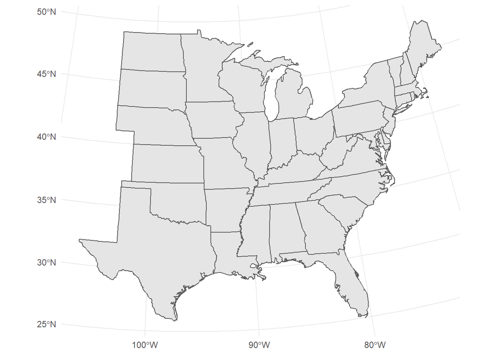

### Presence/absence data

- `Presence`: The crop was planted in this pixels more than twice from 2008 to 2019.
- `Absence`: The crop was *never* planted in this pixel from 2008 to 2019.

```r
#  Build crop frequency shapefiles

# generate random points in ROI
set.seed(300)
rpt <- st_as_sf(spsample(roi, n = 2500000, "random")) # big n needed to ensure 10K AP for each crop

state_names <- unique(states$STATE_NAME)
num_cores <- detectCores() - 3
clus <- makeCluster(num_cores)
registerDoParallel(clus)
out <- build_freq_points(num_cores, state_names) # see CS_func.R
stopCluster(clus)

# frequency count through time
ap <- st_set_geometry(out %>% select(contains("x")), NULL)

fdf <- list()
for (i in 1:length(crop_dc_list)) {
  vls <- crop_dc_list[[i]]
  makec <- function(r) paste('ap==', r, '|')
  stmt <- paste((unlist(lapply(vls, FUN = makec))), collapse='')
  stmt <- substr(stmt, 1, nchar(stmt)-1)
  fdf[[i]] <- as.vector(rowSums(eval(parse(text=stmt)), na.rm=T))
}
fdf <- do.call("cbind.data.frame", fdf)
colnames(fdf) <- crop_names
final <- st_as_sf(cbind.data.frame(out, fdf))

# remove weak presence rows
corn <- final %>% filter(!Corn %in% c(1:2))
cotton <- final %>% filter(!Cotton %in% c(1:2))
soy <- final %>% filter(!Soy %in% c(1:2))
swheat <- final %>% filter(!Swheat %in% c(1:2))
wwheat <- final %>% filter(!Wwheat %in% c(1:2))
alfalfa <- final %>% filter(!Alfalfa %in% c(1:2))
hay <- final %>% filter(!Hay %in% c(1:2))
freq <- list(corn, cotton, soy, swheat, wwheat, alfalfa, hay)

n <- 10000
for (i in 1:length(freq)) {
  df <- as.data.frame(freq[i])
  a <- df %>% filter(!!as.symbol(crop_names[i]) == 0)
  a <- a[sample(nrow(a), n), ]
  a$TYPE <- 0
  p <- df %>% filter(!!as.symbol(crop_names[i]) > 0)
  p <- p[sample(nrow(p), n), ]
  p$TYPE <- 1
  f <- rbind.data.frame(a, p)
  print(paste0(crop_names[i], nrow(f)))
  saveRDS(f, paste0("./out/", crop_names[i], "_AP.RDS"))
}

#  Merge into single shapefile
corn <- clean_AP_data("Corn") # CS_func.R
corn$CROP <- "CORN"
cotton <- clean_AP_data("Cotton")
cotton$CROP <- "COTTON"
soy <- clean_AP_data("Soy")
soy$CROP <- "SOY"
swheat <- clean_AP_data("Swheat")
swheat$CROP <- "SWHEAT"
wwheat <- clean_AP_data("Wwheat")
wwheat$CROP <- "WWHEAT"
alfalfa <- clean_AP_data("Alfalfa")
alfalfa$CROP <- "ALFALFA"
hay <- clean_AP_data("Hay")
hay$CROP <- "HAY"
ap <- rbind.data.frame(corn, cotton, soy, swheat, wwheat, alfalfa, hay)
ap$FID <- as.numeric(1:nrow(ap))
saveRDS(ap, "./out/ap.RDS")
```

Randomly subset 10000 of presence pixels and absence pixels across the ROI.

### Predictors

#### Climate

- Thornton, M.M., P.E. Thornton, Y. Wei, B.W. Mayer, R.B. Cook, and R.S. Vose. 2016. Daymet: Monthly Climate Summaries on a 1-km Grid for North America, Version 3. ORNL DAAC, Oak Ridge, Tennessee, USA. https://doi.org/10.3334/ORNLDAAC/1345

From the annual stacks of this monthly data, I computed the `biovars` variables from the `dismo` package (see full list and description [here](https://www.worldclim.org/data/bioclim.html)). This makes sense because these are also easily available in the future climate projections provided by the WorldClim group.

```r
#  Extract DayMet

# (after running daymet_download.R)

library(dismo)
library(sf)

years <- 1999:2019

pptf <- Sys.glob("C:/Users/eburchf/OneDrive - Emory University/Data/DayMet/prcp_monttl_*")
tminf <- Sys.glob("C:/Users/eburchf/OneDrive - Emory University/Data/DayMet/tmin_monavg*")
tmaxf <- Sys.glob("C:/Users/eburchf/OneDrive - Emory University/Data/DayMet/tmax_monavg*")

for (i in 1:length(years)) {
  print(years[i])
  dir.create(file.path(paste0("C:/Users/eburchf/Desktop/TRASH/",years[i])))
  rasterOptions(tmpdir=file.path(paste0("C:/Users/eburchf/Desktop/TRASH/",years[i])))

  ppt <- stack(pptf[i])
  tmin <- stack(tminf[i])
  tmax <- stack(tmaxf[i])

  roic <- spTransform(roi, tmin@crs)

  ppt <- crop(ppt, roic)
  tmin <- crop(tmin, roic)
  tmax <- crop(tmax, roic)

  bc <- biovars(ppt, tmin, tmax) # takes a sec, 1:07
  writeRaster(bc, paste0("C:/Users/eburchf/OneDrive - Emory University/Data/DayMet/biovars_", years[i],".grd"), overwrite=T)
  unlink(paste0("C:/Users/eburchf/Desktop/TRASH/",years[i]), recursive = TRUE, force = TRUE)
}


# average biovars rasters

bv_list <- Sys.glob(paste0("C:/Users/eburchf/OneDrive - Emory University/Data/DayMet/biovars_*.grd"))
r <- stack(bv_list[1])

for (i in 1:length(bv_list)) {

  r <- stack(bv_list[i])
  print(r@crs)

}

# average of each slice of stack through time

for (i in 1:dim(r)[3]) {

  x <- stack()

  for (f in 1:length(bv_list)) {

    bvr <- stack(bv_list[f])

    bvrs <- bvr[[i]]
    bvrs@crs <- r@crs
    x <- stack(x, bvrs)

  }

  mn <- calc(x, fun = mean, na.rm=T)
  i <- str_pad(i, 2, "left", "0")
  writeRaster(mn, paste0("C:/Users/eburchf/OneDrive - Emory University/Data/DayMet/mn_99_19/bv", i, ".grd"), overwrite=T)
  remove(x, mn)
  }

# extract to points
biovar_list <- sort(Sys.glob("C:/Users/eburchf/OneDrive - Emory University/Data/DayMet/mn_99_19/*.grd"))
biovar <- stack(biovar_list)
# projection information found here: https://cran.r-project.org/web/packages/daymetr/vignettes/daymetr-vignette.html
raster::projection(biovar) <- "+proj=lcc +lat_1=25 +lat_2=60 +lat_0=42.5 +lon_0=-100 +x_0=0 +y_0=0 +a=6378137 +b=6356752.314706705 +units=m +no_defs"
apm <- st_transform(ap, biovar@crs)

bv_ext <- raster::extract(biovar, apm, df=T)
bv_ext$FID <- apm$FID
colnames(bv_ext) <- c("ID", "BV1", "BV2", "BV3", "BV4", "BV5", "BV6", "BV7", "BV8",
                      "BV9", "BV10", "BV11", "BV12", "BV13", "BV14", "BV15", "BV16", "BV17", "BV18", "BV19", "FID")
bv_ext <- bv_ext %>% select(-c(ID))
saveRDS(bv_ext, "./out/biovars_extract.RDS")
```

- Fick, S.E. and R.J. Hijmans, 2017. WorldClim 2: new 1km spatial resolution climate surfaces for global land areas. International Journal of Climatology 37 (12): 4302-4315.

Here’s a list of the `biovars`:

- bio1 = Mean annual temperature
- bio2 = Mean diurnal range (mean of max temp - min temp)
- bio3 = Isothermality (bio2/bio7) (* 100)
- bio4 = Temperature seasonality (standard deviation *100)
- bio5 = Max temperature of warmest month
- bio6 = Min temperature of coldest month
- bio7 = Temperature annual range (bio5-bio6)
- bio8 = Mean temperature of the wettest quarter
- bio9 = Mean temperature of driest quarter
- bio10 = Mean temperature of warmest quarter
- bio11 = Mean temperature of coldest quarter
- bio12 = Total (annual) precipitation
- bio13 = Precipitation of wettest month
- bio14 = Precipitation of driest month
- bio15 = Precipitation seasonality (coefficient of variation)
- bio16 = Precipitation of wettest quarter
- bio17 = Precipitation of driest quarter
- bio18 = Precipitation of warmest quarter
- bio19 = Precipitation of coldest quarter

#### Soil

Given the size of this data and the complexities of wrangling it, it made more sense to focus on the [Harmonized World Soils Database](http://www.fao.org/soils-portal/soil-survey/soil-maps-and-databases/harmonized-world-soil-database-v12/en/) which is a 1 km dataset availble globally. The dataset originally comes in an Access database. Check out the `hwsd.R` script for how to wrangle this into a raster format.

- Wieder, W.R., J. Boehnert, G.B. Bonan, and M. Langseth. 2014. Regridded Harmonized World Soil Database v1.2. Data set. Available on-line [http://daac.ornl.gov] from Oak Ridge National Laboratory Distributed Active Archive Center, Oak Ridge, Tennessee, USA. http://dx.doi.org/10.3334/ORNLDAAC/1247.
- Fischer, G., F. Nachtergaele, S. Prieler, H.T. van Velthuizen, L. Verelst, D. Wiberg, 2008. Global Agro-ecological Zones Assessment for Agriculture (GAEZ 2008). IIASA, Laxenburg, Austria and FAO, Rome, Italy.

```r
# check out hwsd.R for the wizardry.
soil_data <- Sys.glob("C:/Users/eburchf/OneDrive - Emory University/Data/HWSD/rasters/*.tif")
soil_ras <- stack(soil_data)

aps <- st_transform(ap, soil_ras@crs)

soil_ext <- raster::extract(soil_ras, aps, df=T)
soil_ext$FID <- aps$FID
soil_ext$T_ECE <- soil_ext$TS_ECE
soil_ext$T_SAND <- soil_ext$TS_SAND
soil_ext <- soil_ext %>% dplyr::select(-c(ID, TS_ECE, TS_SAND))

saveRDS(soil_ext, "./out/soil_extract.RDS")
```

Notes on other soil datasets:

- Though [gSSURGO](https://www.nrcs.usda.gov/wps/portal/nrcs/detail/soils/home/?cid=nrcs142p2_053628) and [gNATSGO](https://nrcs.app.box.com/v/soils/folder/108071141504) are start-of-the-art in the US, none of the other datasets are at this high 30 meter resolution, so I’d end up resampling anyways and coarsening this data.[^2]
- Coarser resolution [STATSGO2](https://www.nrcs.usda.gov/wps/portal/nrcs/detail/soils/survey/geo/?cid=nrcs142p2_053629) data. “…a broad-based inventory of soils and non-soil areas” - SSURGO seems far too detailed given our scope, so STATSGO2 should be sufficient ([this presentation](https://nrcs.app.box.com/v/soils/file/643765519602) visualizes the differences). Also [gNATSGO CONUS download](https://nrcs.app.box.com/v/soils/folder/108071141504).
- Overview of available soil data [here](https://www.nrcs.usda.gov/wps/portal/nrcs/detail/soils/survey/tools/?cid=nrcseprd1407030).

#### Irrigation

MIRAD 1km meter 2002, 2007, 2012, 2017 downloaded [here](https://www.sciencebase.gov/catalog/item/5db08e84e4b0b0c58b56e04f). This is the percent irrigated (based on 250 meter dataset) in a 1 km cell. I defined a 1 km pixel as irrigated if any of this 1 km cell was listed as irrigated… this flexible definition works in my mind, allows for irrigation expansion in the future - though I should/could test sensitivity to different definitions, e.g. a 50% threshold.

- Brown, J.F., Howard, D.M., Shrestha, D., and Benedict, T.D., 2019, Moderate Resolution Imaging Spectroradiometer (MODIS) Irrigated Agriculture Datasets for the Conterminous United States (MIrAD-US): U.S. Geological Survey data release, https://doi.org/10.5066/P9NA3EO8.

```r
# 2012 as "baseline"
mirad_list <- Sys.glob("C:/Users/eburchf/OneDrive - Emory University/Data/MIRAD/mirad1km*.tif")
mirad <- stack(mirad_list)
apm <- st_transform(ap, mirad@crs)

mirad_ext <- raster::extract(mirad, apm, df=T)
mirad_ext$FID <- apm$FID
colnames(mirad_ext) <- c("ID", "IRR_02", "IRR_07", "IRR_12", "IRR_17", "FID")
mirad_ext <- mirad_ext %>% select(-c("ID"))
mirad_ext$IRR_AVG <- rowMeans(mirad_ext[,c("IRR_02", "IRR_07", "IRR_12", "IRR_17")])
mirad_ext$IRR_ZERO <- ifelse(mirad_ext$IRR_AVG > 0, 1, 0)
mirad_ext$IRR_50 <- ifelse(mirad_ext$IRR_AVG > 50, 1, 0)
saveRDS(mirad_ext, "./out/mirad_extract.RDS")
```

#### Topography

To align with the other 1 km datasets, I used the [North American 1-km resolution GRID](https://www.sciencebase.gov/catalog/item/4fb5495ee4b04cb937751d6d). This includes only elevation (m). I computed slope in ArcGIS using the Spatial Analyst, Slope tool (Output measurement: DEGREE, Method: PLANAR, Z factor: 1, Z unit: METR)

```r
s <- raster("C:/Users/eburchf/OneDrive - Emory University/Data/DEM/NA_1KM_SLOPE.tif")
d <- raster("C:/Users/eburchf/OneDrive - Emory University/Data/DEM/NA_1KM.tif")
topo <- stack(s, d)
aps <- st_transform(ap, s@crs)

topo_ext <- extract(topo, aps, df=T)
topo_ext$FID <- aps$FID
colnames(topo_ext) <- c("ID", "SLOPE", "ELEVATION", "FID")
topo_ext$ELEVATION[is.na(topo_ext$ELEVATION)] <- 0
topo_ext <- topo_ext %>% dplyr::select(-c(ID))
saveRDS(topo_ext, "./out/topo_extract.RDS")
```

Other datasets:

- 30 meter Landfire data, downloadable from [this website](https://www.landfire.gov/version_comparison.php) (LF REMAP LF 2.0.0). More information on slope data [here](https://www.landfire.gov/slope.php) and on elevation [here](https://www.landfire.gov/elevation.php). I opened in Arc since it was a file geodatabase and wrote out as `LF_slope.tif` and `LF_elevation.tif` in the DEM folder.
[^1]: Note, dropped Sweet Corn and Popcorn since this was not included in the National Crop Frequency Layer.
[^2]: Download data [here](https://gdg.sc.egov.usda.gov/GDGOrder.aspx?order=QuickState). Also available is the [gNATSGO](https://nrcs.app.box.com/v/soils/folder/108071141504) dataset, most up-to-date, high resolution.